# Descriptive_Statistics

Debit Paudel

12/2/2021

## R Markdown

```r
data_iris <- iris
data_iris
```

```
##     Sepal.Length Sepal.Width Petal.Length Petal.Width    Species
## 1            5.1         3.5          1.4         0.2     setosa
## 2            4.9         3.0          1.4         0.2     setosa
## 3            4.7         3.2          1.3         0.2     setosa
## 4            4.6         3.1          1.5         0.2     setosa
## 5            5.0         3.6          1.4         0.2     setosa
## 6            5.4         3.9          1.7         0.4     setosa
## 7            4.6         3.4          1.4         0.3     setosa
## 8            5.0         3.4          1.5         0.2     setosa
## 9            4.4         2.9          1.4         0.2     setosa
## 10           4.9         3.1          1.5         0.1     setosa
## 11           5.4         3.7          1.5         0.2     setosa
## 12           4.8         3.4          1.6         0.2     setosa
## 13           4.8         3.0          1.4         0.1     setosa
## 14           4.3         3.0          1.1         0.1     setosa
```

[output cut: 136 more lines]

The dataset contains 150 observations and 5 variables, representing the length and width of the sepal and petal and the species of 150 flowers.

**Minimum and maximum**.

We can find using max() and min () functions.

```r
min(data_iris$Sepal.Width)
```

```
## [1] 2
```

```r
max(data_iris$Sepal.Width)
```

```
## [1] 4.4
```

The **Range** also gives minimun and maximum.

```r
rnge<-range(data_iris$Sepal.Width)
rnge
```

```
## [1] 2.0 4.4
```

It is shown in like a array.we can differentiate using

```r
rnge[1]
```

```
## [1] 2
```

**Mean** and **Meadian** can be calculated uding mean() function

```r
mean(data_iris$Sepal.Width)
```

```
## [1] 3.057333
```

```r
median(data_iris$Sepal.Width)
```

```
## [1] 3
```

The **First Quartile**,**Third Quartile** as well *IQR* have functions and can be calculated like below:

```r
quantile(data_iris$Sepal.Width, 0.25)
```

```
## 25%
## 2.8
```

For the Third quartile we just need to change second parameter as **0.75**

```r
IQR(data_iris$Sepal.Width)
```

```
## [1] 0.5
```

**Standard deviation and variance**

The standard deviation and the variance is calculated with the sd() and var() functions:

```r
sd(data_iris$Sepal.Width)
```

```
## [1] 0.4358663
```

```r
var(data_iris$Sepal.Width)
```

```
## [1] 0.1899794
```

**Summary** Summary will give summary for all the variables by just a function summary()

```r
summary(data_iris)
```

```
##   Sepal.Length    Sepal.Width     Petal.Length    Petal.Width
##  Min.   :4.300   Min.   :2.000   Min.   :1.000   Min.   :0.100
##  1st Qu.:5.100   1st Qu.:2.800   1st Qu.:1.600   1st Qu.:0.300
##  Median :5.800   Median :3.000   Median :4.350   Median :1.300
##  Mean   :5.843   Mean   :3.057   Mean   :3.758   Mean   :1.199
##  3rd Qu.:6.400   3rd Qu.:3.300   3rd Qu.:5.100   3rd Qu.:1.800
##  Max.   :7.900   Max.   :4.400   Max.   :6.900   Max.   :2.500
##        Species
##  setosa    :50
##  versicolor:50
##  virginica :50
##
##
##
```

If we need the descriptive statistics by group we can apply by() function

```r
by(data_iris, data_iris$Species, summary)
```

```
## data_iris$Species: setosa
##   Sepal.Length    Sepal.Width     Petal.Length    Petal.Width
##  Min.   :4.300   Min.   :2.300   Min.   :1.000   Min.   :0.100
##  1st Qu.:4.800   1st Qu.:3.200   1st Qu.:1.400   1st Qu.:0.200
##  Median :5.000   Median :3.400   Median :1.500   Median :0.200
##  Mean   :5.006   Mean   :3.428   Mean   :1.462   Mean   :0.246
##  3rd Qu.:5.200   3rd Qu.:3.675   3rd Qu.:1.575   3rd Qu.:0.300
##  Max.   :5.800   Max.   :4.400   Max.   :1.900   Max.   :0.600
##        Species
##  setosa    :50
##  versicolor: 0
##  virginica : 0
##
##
##
## ------------------------------------------------------------
## data_iris$Species: versicolor
##   Sepal.Length    Sepal.Width     Petal.Length   Petal.Width          Species
##  Min.   :4.900   Min.   :2.000   Min.   :3.00   Min.   :1.000   setosa    : 0
##  1st Qu.:5.600   1st Qu.:2.525   1st Qu.:4.00   1st Qu.:1.200   versicolor:50
##  Median :5.900   Median :2.800   Median :4.35   Median :1.300   virginica : 0
##  Mean   :5.936   Mean   :2.770   Mean   :4.26   Mean   :1.326
##  3rd Qu.:6.300   3rd Qu.:3.000   3rd Qu.:4.60   3rd Qu.:1.500
##  Max.   :7.000   Max.   :3.400   Max.   :5.10   Max.   :1.800
## ------------------------------------------------------------
## data_iris$Species: virginica
##   Sepal.Length    Sepal.Width     Petal.Length    Petal.Width
##  Min.   :4.900   Min.   :2.200   Min.   :4.500   Min.   :1.400
##  1st Qu.:6.225   1st Qu.:2.800   1st Qu.:5.100   1st Qu.:1.800
##  Median :6.500   Median :3.000   Median :5.550   Median :2.000
##  Mean   :6.588   Mean   :2.974   Mean   :5.552   Mean   :2.026
##  3rd Qu.:6.900   3rd Qu.:3.175   3rd Qu.:5.875   3rd Qu.:2.300
##  Max.   :7.900   Max.   :3.800   Max.   :6.900   Max.   :2.500
##        Species
##  setosa    : 0
##  versicolor: 0
##  virginica :50
##
##
##
```

Plotting the histogram for the Sepal width

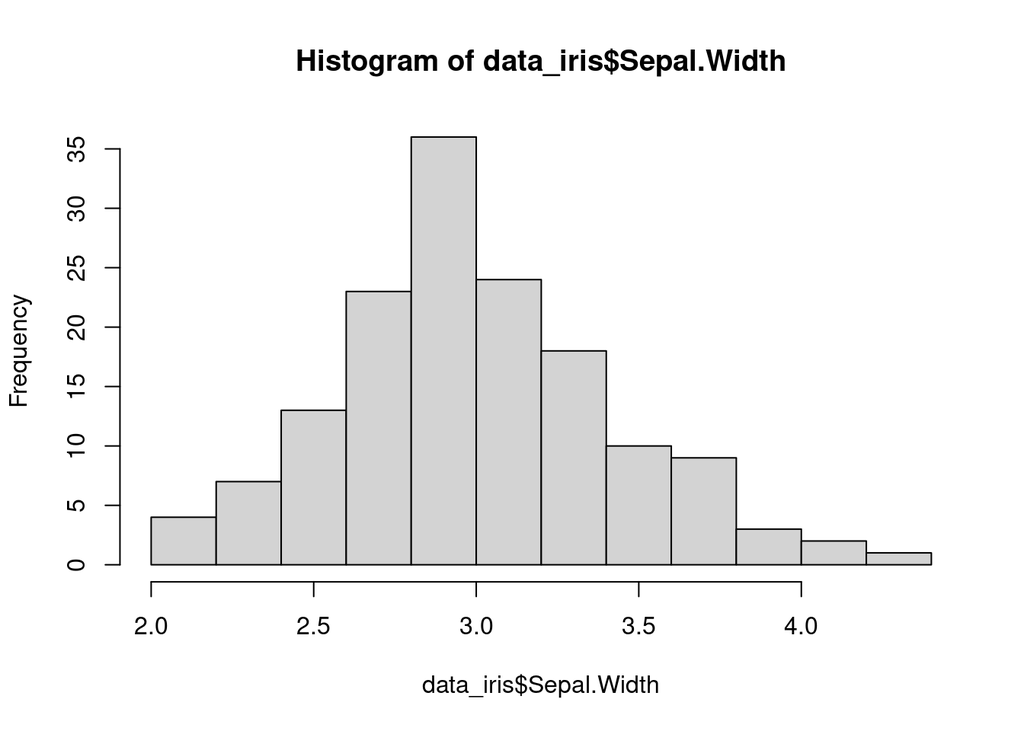

```r
hist(data_iris$Sepal.Width)
```

**BoxPlot**.

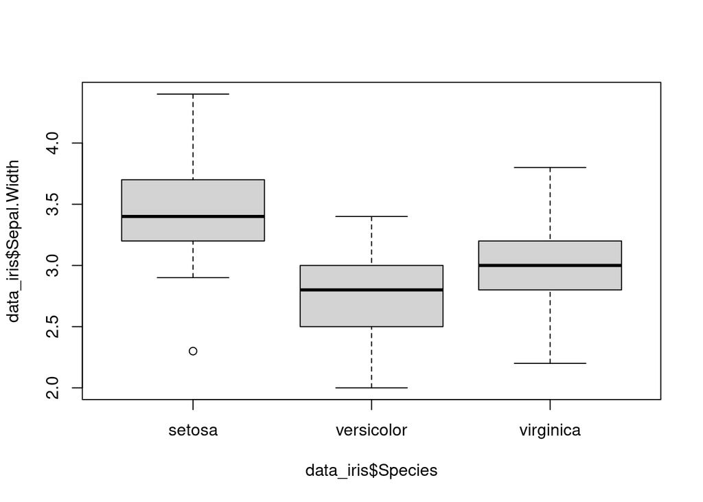

```r
boxplot(data_iris$Sepal.Width ~ data_iris$Species)
```

**Frequency tables with** freq() The freq() function produces frequency tables with frequencies, proportions, as well as missing data information.

```r
library(summarytools)
freq(data_iris$Species)
```

```
## Frequencies
## data_iris$Species
## Type: Factor
##
##                    Freq   % Valid   % Valid Cum.   % Total   % Total Cum.
## ---------------- ------ --------- -------------- --------- --------------
##           setosa     50     33.33          33.33     33.33          33.33
##       versicolor     50     33.33          66.67     33.33          66.67
##        virginica     50     33.33         100.00     33.33         100.00
##             <NA>      0                               0.00         100.00
##            Total    150    100.00         100.00    100.00         100.00
```